# Assignment 1 - Reprodusible Research

1. Loading and preprocessing the data

The data is downloaded from the website and is located on the corresponding folder. Afterwards, it's unzipped and the missing values are ommited.

```r
file <- "repdata_data_activity.zip"
if (!file.exists(file)) {
  download <- "https://d396qusza40orc.cloudfront.net/repdata%2Fdata%2Factivity.zip"
 download.file(download, destfile = file)
 unzip (zipfile = file)
}
data_original_form <- read.csv("activity.csv", header = TRUE)
working_data <- na.omit(data_original_form)
head(working_data)
```

```
##     steps       date interval
## 289     0 2012-10-02        0
## 290     0 2012-10-02        5
## 291     0 2012-10-02       10
## 292     0 2012-10-02       15
## 293     0 2012-10-02       20
## 294     0 2012-10-02       25
```

2. What is mean total number of steps taken per day?

First, the total number of daily steps is calculated by aggregating the steps for each day

```r
steps_day <- aggregate(working_data$steps, by = list(Steps.Date = working_data$date), FUN = "sum")
```

Second, a histogram is constructed, which shows the frequency of the different number of steps per day

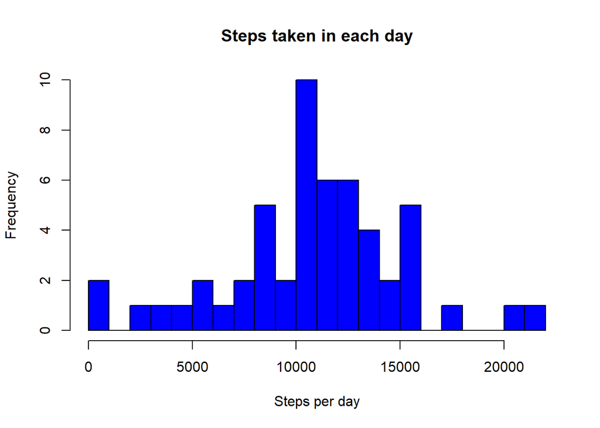

```r
hist(steps_day$x, col = "blue",
     breaks = 30,
     main = "Steps taken in each day",
     xlab = "Steps per day")
```

The mean and median number of steps are calculated. Here we observe that they are slightly different.

```r
mean(steps_day[,2], na.rm = TRUE)
```

```
## [1] 10766.19
```

```r
median(steps_day[,2], na.rm = TRUE)
```

```
## [1] 10765
```

3. What is the average daily activity pattern?

The average daily activity pattern is obtained by calculating the mean of the steps for each 5-minute interval.

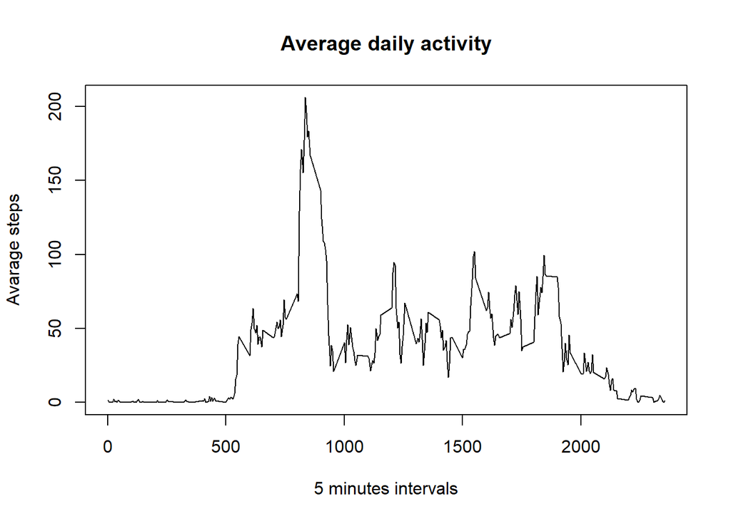

```r
average_activity <- aggregate(working_data$steps,
                          by = list(Interval = working_data$interval),
                          FUN = "mean")
plot(average_activity$Interval, average_activity$x, type = "l",
     main = "Average daily activity",
     ylab = "Avarage steps",
     xlab = "5 minutes intervals")
```

Which 5-minute interval, on average across all the days in the dataset, contains the maximum number of steps?

Afterwards, we identify the 5-minute interval which is associated with the maximum number of average steps.

```r
interval_max <- which.max(average_activity$x)
max_interval <- average_activity[interval_max,1]
print (max_interval)
```

```
## [1] 835
```

4. Imputing missing values

The number of missing values is identified and tabulated.

```r
missing_values <- is.na(data_original_form$steps)
table(missing_values)
```

```
## missing_values
## FALSE  TRUE
## 15264  2304
```

```r
library(Hmisc)
original_data_filled <- data_original_form
original_data_filled$steps <- impute(data_original_form$steps, fun=mean)
head(original_data_filled)
```

```
##     steps       date interval
## 1 37.3826 2012-10-01        0
## 2 37.3826 2012-10-01        5
## 3 37.3826 2012-10-01       10
## 4 37.3826 2012-10-01       15
## 5 37.3826 2012-10-01       20
## 6 37.3826 2012-10-01       25
```

The histogram of the total number of steps generated with the new imputed database is calculated.

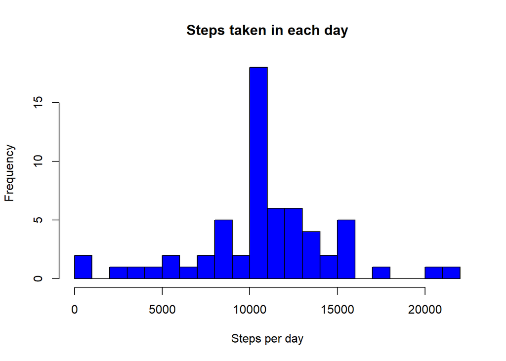

```r
steps_day_imputed <- aggregate(original_data_filled$steps, by = list(Steps.Date = original_data_filled$date), FUN = "sum")
hist(steps_day_imputed$x, col = "blue",
     breaks = 30,
     main = "Steps taken in each day",
     xlab = "Steps per day")
```

The mean and the median are reported, which right now are equal.

```r
mean(steps_day_imputed[,2], na.rm = TRUE)
```

```
## [1] 10766.19
```

```r
median(steps_day_imputed[,2], na.rm = TRUE)
```

```
## [1] 10766.19
```

5. Are there differences in activity patterns between weekdays and weekends?

A new factor variable is created. This variable indicates if the specific date belongs to a weekday or a weekend.

```r
original_data_filled$date <- as.Date(strptime(original_data_filled$date, format="%Y-%m-%d"))
original_data_filled$datetype <- sapply(original_data_filled$date, function(x) {
  if (weekdays(x) == "Saturday" | weekdays(x) =="Sunday")
  {y <- "Weekend"} else
  {y <- "Weekday"}
  y
})
head(original_data_filled)
```

```
##     steps       date interval datetype
## 1 37.3826 2012-10-01        0  Weekday
## 2 37.3826 2012-10-01        5  Weekday
## 3 37.3826 2012-10-01       10  Weekday
## 4 37.3826 2012-10-01       15  Weekday
## 5 37.3826 2012-10-01       20  Weekday
## 6 37.3826 2012-10-01       25  Weekday
```

Finally, time series plot showing the average number of steps (y axis) by interval (x axis) for weekdays and weekends are generated

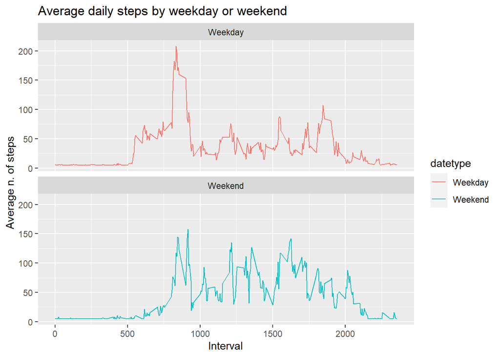

```r
activity_date <- aggregate(steps~interval + datetype, original_data_filled, mean, na.rm = TRUE)
plot<- ggplot(activity_date, aes(x = interval , y = steps, color = datetype)) +
  geom_line() +
  labs(title = "Average daily steps by weekday or weekend", x = "Interval", y = "Average n. of steps") +
  facet_wrap(~datetype, ncol = 1, nrow=2)
print(plot)
```